# Prosper Loan Data Exploration

### by Naomi Ayibaemi Frank-Opigo

## Introduction

This document explores a dataset that contains borrower data and loan data for 113937 loan listings in the USA.

## Preliminary Wrangling

```python
# import all packages and set plots to be embedded inline
import numpy as np
import pandas as pd
import matplotlib.pyplot as plt
import seaborn as sb
import dask.dataframe as dd

%matplotlib inline
```

```python
#Load data
loan = pd.read_csv('prosperLoanData.csv')

#Assessing data column information and preview of dataset
print(loan.shape)
print(loan.info())
loan.head()
```

```
(113937, 81)
<class 'pandas.core.frame.DataFrame'>
RangeIndex: 113937 entries, 0 to 113936
Data columns (total 81 columns):
 #   Column                               Non-Null Count   Dtype
---  ------                               --------------   -----
 0   ListingKey                           113937 non-null  object
 1   ListingNumber                        113937 non-null  int64
 2   ListingCreationDate                  113937 non-null  object
 3   CreditGrade                          28953 non-null   object
 4   Term                                 113937 non-null  int64
 5   LoanStatus                           113937 non-null  object
 6   ClosedDate                           55089 non-null   object
 7   BorrowerAPR                          113912 non-null  float64
 8   BorrowerRate                         113937 non-null  float64
```

[output cut: 75 more lines]

|  | ListingKey | ListingNumber | ListingCreationDate | CreditGrade | Term | LoanStatus | ClosedDate | BorrowerAPR | BorrowerRate | LenderYield | ... | LP_ServiceFees | LP_CollectionFees | LP_GrossPrincipalLoss | LP_NetPrincipalLoss | LP_NonPrincipalRecoverypayments | PercentFunded | Recommendations | InvestmentFromFriendsCount | InvestmentFromFriendsAmount | Investors |
| --- | --- | --- | --- | --- | --- | --- | --- | --- | --- | --- | --- | --- | --- | --- | --- | --- | --- | --- | --- | --- | --- |
| 0 | 1021339766868145413AB3B | 193129 | 2007-08-26 19:09:29.263000000 | C | 36 | Completed | 2009-08-14 00:00:00 | 0.16516 | 0.1580 | 0.1380 | ... | -133.18 | 0.0 | 0.0 | 0.0 | 0.0 | 1.0 | 0 | 0 | 0.0 | 258 |
| 1 | 10273602499503308B223C1 | 1209647 | 2014-02-27 08:28:07.900000000 | NaN | 36 | Current | NaN | 0.12016 | 0.0920 | 0.0820 | ... | 0.00 | 0.0 | 0.0 | 0.0 | 0.0 | 1.0 | 0 | 0 | 0.0 | 1 |
| 2 | 0EE9337825851032864889A | 81716 | 2007-01-05 15:00:47.090000000 | HR | 36 | Completed | 2009-12-17 00:00:00 | 0.28269 | 0.2750 | 0.2400 | ... | -24.20 | 0.0 | 0.0 | 0.0 | 0.0 | 1.0 | 0 | 0 | 0.0 | 41 |
| 3 | 0EF5356002482715299901A | 658116 | 2012-10-22 11:02:35.010000000 | NaN | 36 | Current | NaN | 0.12528 | 0.0974 | 0.0874 | ... | -108.01 | 0.0 | 0.0 | 0.0 | 0.0 | 1.0 | 0 | 0 | 0.0 | 158 |
| 4 | 0F023589499656230C5E3E2 | 909464 | 2013-09-14 18:38:39.097000000 | NaN | 36 | Current | NaN | 0.24614 | 0.2085 | 0.1985 | ... | -60.27 | 0.0 | 0.0 | 0.0 | 0.0 | 1.0 | 0 | 0 | 0.0 | 20 |

5 rows × 81 columns

```python
#Changing data types
#Converting Listing Creation Date,Closed Date, First Recorded Credit Line and Loan Origination Date to datetime data
loan[['ListingCreationDate','ClosedDate','FirstRecordedCreditLine','LoanOriginationDate']]=loan[['ListingCreationDate','ClosedDate','FirstRecordedCreditLine','LoanOriginationDate']].apply(pd.to_datetime)

#Extracting year from listing creation  date into a separate column
loan['Year'] = loan['ListingCreationDate'].dt.year

#Extracting quarter from listing creation date into a separate column
loan['Quarter'] = loan['ListingCreationDate'].dt.quarter
```

```python
#converting loan status, prosper rating (numeric),prosper rating (alphabetilcal), prosper score,listing category (numeric),loan origination quarter, income range and quarter to categorical data
loan[['LoanStatus','ProsperRating (numeric)', 'ProsperRating (Alpha)','ProsperScore','ListingCategory (numeric)','LoanOriginationQuarter','IncomeRange', 'Quarter']]=loan[['LoanStatus','ProsperRating (numeric)', 'ProsperRating (Alpha)','ProsperScore','ListingCategory (numeric)','LoanOriginationQuarter', 'IncomeRange','Quarter']].apply(lambda x: x.astype('category'))
```

```python
loan['ListingNumber']=loan['ListingNumber'].astype('string')
```

```python
loan.info()
```

```
<class 'pandas.core.frame.DataFrame'>
RangeIndex: 113937 entries, 0 to 113936
Data columns (total 83 columns):
 #   Column                               Non-Null Count   Dtype
---  ------                               --------------   -----
 0   ListingKey                           113937 non-null  object
 1   ListingNumber                        113937 non-null  string
 2   ListingCreationDate                  113937 non-null  datetime64[ns]
 3   CreditGrade                          28953 non-null   object
 4   Term                                 113937 non-null  int64
 5   LoanStatus                           113937 non-null  category
 6   ClosedDate                           55089 non-null   datetime64[ns]
 7   BorrowerAPR                          113912 non-null  float64
 8   BorrowerRate                         113937 non-null  float64
 9   LenderYield                          113937 non-null  float64
```

[output cut: 75 more lines]

```python
#Assessing the statistic summary of numeric variables
loan.describe()
```

|  | Term | BorrowerAPR | BorrowerRate | LenderYield | EstimatedEffectiveYield | EstimatedLoss | EstimatedReturn | EmploymentStatusDuration | CreditScoreRangeLower | CreditScoreRangeUpper | ... | LP_CollectionFees | LP_GrossPrincipalLoss | LP_NetPrincipalLoss | LP_NonPrincipalRecoverypayments | PercentFunded | Recommendations | InvestmentFromFriendsCount | InvestmentFromFriendsAmount | Investors | Year |
| --- | --- | --- | --- | --- | --- | --- | --- | --- | --- | --- | --- | --- | --- | --- | --- | --- | --- | --- | --- | --- | --- |
| count | 113937.000000 | 113912.000000 | 113937.000000 | 113937.000000 | 84853.000000 | 84853.000000 | 84853.000000 | 106312.000000 | 113346.000000 | 113346.000000 | ... | 113937.000000 | 113937.000000 | 113937.000000 | 113937.000000 | 113937.000000 | 113937.000000 | 113937.000000 | 113937.000000 | 113937.000000 | 113937.000000 |
| mean | 40.830248 | 0.218828 | 0.192764 | 0.182701 | 0.168661 | 0.080306 | 0.096068 | 96.071582 | 685.567731 | 704.567731 | ... | -14.242698 | 700.446342 | 681.420499 | 25.142686 | 0.998584 | 0.048027 | 0.023460 | 16.550751 | 80.475228 | 2011.012481 |
| std | 10.436212 | 0.080364 | 0.074818 | 0.074516 | 0.068467 | 0.046764 | 0.030403 | 94.480605 | 66.458275 | 66.458275 | ... | 109.232758 | 2388.513831 | 2357.167068 | 275.657937 | 0.017919 | 0.332353 | 0.232412 | 294.545422 | 103.239020 | 2.504353 |
| min | 12.000000 | 0.006530 | 0.000000 | -0.010000 | -0.182700 | 0.004900 | -0.182700 | 0.000000 | 0.000000 | 19.000000 | ... | -9274.750000 | -94.200000 | -954.550000 | 0.000000 | 0.700000 | 0.000000 | 0.000000 | 0.000000 | 1.000000 | 2005.000000 |
| 25% | 36.000000 | 0.156290 | 0.134000 | 0.124200 | 0.115670 | 0.042400 | 0.074080 | 26.000000 | 660.000000 | 679.000000 | ... | 0.000000 | 0.000000 | 0.000000 | 0.000000 | 1.000000 | 0.000000 | 0.000000 | 0.000000 | 2.000000 | 2008.000000 |
| 50% | 36.000000 | 0.209760 | 0.184000 | 0.173000 | 0.161500 | 0.072400 | 0.091700 | 67.000000 | 680.000000 | 699.000000 | ... | 0.000000 | 0.000000 | 0.000000 | 0.000000 | 1.000000 | 0.000000 | 0.000000 | 0.000000 | 44.000000 | 2012.000000 |
| 75% | 36.000000 | 0.283810 | 0.250000 | 0.240000 | 0.224300 | 0.112000 | 0.116600 | 137.000000 | 720.000000 | 739.000000 | ... | 0.000000 | 0.000000 | 0.000000 | 0.000000 | 1.000000 | 0.000000 | 0.000000 | 0.000000 | 115.000000 | 2013.000000 |
| max | 60.000000 | 0.512290 | 0.497500 | 0.492500 | 0.319900 | 0.366000 | 0.283700 | 755.000000 | 880.000000 | 899.000000 | ... | 0.000000 | 25000.000000 | 25000.000000 | 21117.900000 | 1.012500 | 39.000000 | 33.000000 | 25000.000000 | 1189.000000 | 2014.000000 |

8 rows × 58 columns

```python
loan['LoanOriginalAmount'].describe()
```

```
count    113937.00000
mean       8337.01385
std        6245.80058
min        1000.00000
25%        4000.00000
50%        6500.00000
75%       12000.00000
max       35000.00000
Name: LoanOriginalAmount, dtype: float64
```

### What is the structure of your dataset?

There are 113,937 loan entries with 81 details each. The data types include : floats, integers,datetime, categorical, boolean and string. Most variables are numeric. The following variables have fixed categories or ranges:

1. Prosper rating (numeric) : 0 - N/A, 1 - HR, 2 - E, 3 - D, 4 - C, 5 - B, 6 - A, 7 - AA.
2. Prosper rating(alpha) : AA -HR
3. Prosper score : 1-10 (10 = lowest risk, 1 = highest risk), above 10 others are stated as 11
4. Listing category: 0 - Not Available, 1 - Debt Consolidation, 2 - Home Improvement, 3 - Business, 4 - Personal Loan, 5 - Student Use, 6 - Auto, 7- Other, 8 - Baby&Adoption, 9 - Boat, 10 - Cosmetic Procedure, 11 - Engagement Ring, 12 - Green Loans, 13 - Household Expenses, 14 - Large Purchases, 15 - Medical/Dental, 16 - Motorcycle, 17 - RV, 18 - Taxes, 19 - Vacation, 20 - Wedding Loans
5. Debt to income ratio : values above 1000% are indicated by 1001%

### What is/are the main feature(s) of interest in your dataset?

I am interested in looking at the original loan amount. I want to explore how variables such as Home ownership,Listing category Prosper score, Occupations, regions, income range, time and other relate to the original loan amount given to loan seekers.

### What features in the dataset do you think will help support your investigation into your feature(s) of interest?

- Original loan amount
- Home Ownership
- Income range
- Prosper score
- Investors
- Borrower APR
- Listing Category
- Employment Status
- Lender Yield
- Borrower state
- Listing Creation Date

## Univariate Exploration

> I will first explore the main variable of interest - **Original loan amount**

#### U.Fig-1 : What's the distribution of Original Loan amount ?

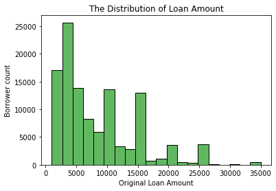

```python
#Defining the theme color to be used for visualisations
colour = sb.color_palette()[2]

#a histigram of Original Loan amount
sb.histplot( loan['LoanOriginalAmount'], bins= 20, kde= False, color= colour)

#Setting plot labels & title
plt.xlabel('Original Loan Amount')
plt.ylabel('Borrower count')
plt.title('The Distribution of Loan Amount');
```

#### Observation

This is the main variable of interest. The graph shows a generalized decrease in number of loans as the loan amount increases except for odd peaks at 10,000 -15,000. The loan amount with the highest borrower count is 4,000 USD

> Next up is the **homeowner status**, a boolean variable that is easy to asses. Home ownership makes for easy access to loan collateral and may therefore have significant effect on a borrower's loan seeking behaviour

#### U.Fig-2 : Are more borrowers home owners?

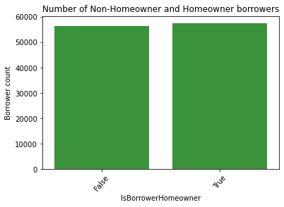

```python
#countplot of Homeowners and Non-Homeowners
sb.countplot ( data = loan, x = 'IsBorrowerHomeowner', color = colour)

#Rotating x-xis ticks for visibility and setting plot title
plt.xticks (rotation=50)
plt.ylabel('Borrower count')
plt.title('Number of Non-Homeowner and Homeowner borrowers');
```

#### Observation

A look at the homeowner statistics.Surprisingly, the distribution of loans between home-owners and non-homeowners is almost equal even though a slightly larger number of borrowers are homeowners.

> Another major variable of interest is the borrower **income range** as it could possibly affect a borrower's tendency to seek loans as well as capacity to pay back loans

#### U.Fig-3 : Which income range takes out the most loans

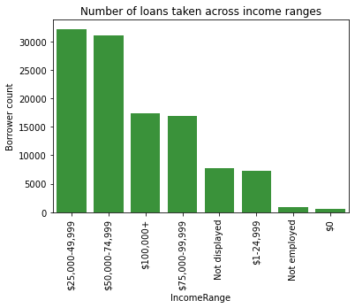

```python
#countplot of the Income ranges

#setting bar order
bar_order=loan['IncomeRange'].value_counts().index
#Income range is a categorical data with the categories as follows: Not displayed, Not employed, $0, $1-24,999, $25,000-49,999, $50,000-74,999, $75,000-99,000. $100,000+
sb.countplot( data = loan, x='IncomeRange', color = colour, order = bar_order)

#Setting plot labels & title
plt.xticks(rotation= 90)
plt.ylabel('Borrower count')
plt.title('Number of loans taken across income ranges');
```

#### Observation

Most borrowers are in the lower middle class to middle class income range. Fewer borrowers earn above 100,000+. Borrowers with earnings categorized as "Not displayed","1-24,999", "0" are few. Some borrowers indicate that they are not employed.

> The next variable to be explored is the **prosper score**. This ranges from 1 - 10 with 10 being low risk borrowe and 1 being a high risk borrower. The prosper score could potentially determine the confidence the lender institution has in a borrower and whether or not a borrower recieves approval for a loan

#### U.Fig-4 : What prosper scores have the largest number of loans

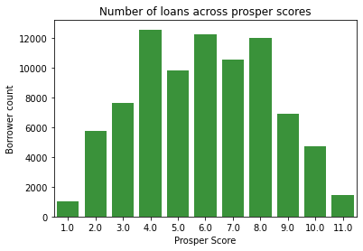

```python
#A countplot displaying the number of loans across the different prosper scores
sb.countplot(data =loan, x= 'ProsperScore', color = colour)

#Setting axis label & plot title
plt.xlabel('Prosper Score')
plt.ylabel('Borrower count')
plt.title('Number of loans across prosper scores');
```

#### Observation

The prosper score shows a normal distributionwith the highest peaks falling between 4.0 and 8.0

> A high **number of investors** a borrower has is expected to inspire confidence in lender institutions. It is assumed then that borrowers will seek to draw investors before applying for loans

#### U.Fig-5 : Are borrowers with more investors more likely to get loans?

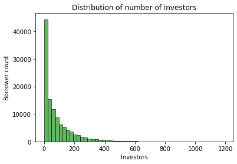

```python
#A histogram representing the distribution of number of investors for loan seekers
sb.histplot(loan['Investors'], bins=50, kde= False, color =colour)

#Setting y-axis label & plot title
plt.ylabel('Borrower count')
plt.title('Distribution of number of investors');
```

#### Observation

There's an initial spike after which the graph shows a consistent decline indicating that a large number of borrowers have few, if any, investors. Very few form the exception having at least over 200 investors.This result is contrary to the original assumption as it shows that borrowers do not place a high value on garnering investors before applying for loans

> Next up, the **employment status** of borrowers is explored. This is also a key variable as a steady source of income can play a role in determining the borrower's prosper score. Stable income can also allow borrower's to be confident in seeking out high loan amounts.

#### U.Fig-6: What is the majority employment status of borrowers

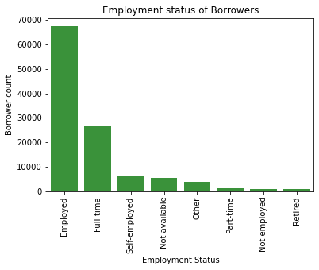

```python
#Ordering the bars in descending order
bar_order= loan['EmploymentStatus'].value_counts().index
# a countplot displaying the number of loan seekers  based on their employment statuses
sb.countplot(data = loan, x ='EmploymentStatus', order = bar_order, color = colour)

#Rotating x-axis ticks to avoid overlap
plt.xticks(rotation=90)

#Setting axis label and plot title
plt.xlabel('Employment Status')
plt.ylabel('Borrower count')
plt.title('Employment status of Borrowers');
```

#### Observation

The borrower poulation is largely employed. Unemployed & retired borrowers as well as borrowers that indicated "other" form the minority. This might be an indicator towards the effect of the employment and income source on loan disbursal.

> Considering the main variable of interest is the Original loan amount, it is also interesting to look at the variable up next. The **borrower APR** is essentially the annual interest rate.

#### U.Fig-7: How is Borrower APR distributed

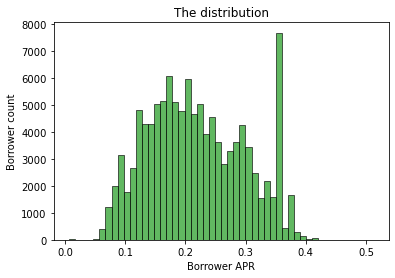

```python
#A histogram showing the distribution of Borrower APR
sb.histplot( loan['BorrowerAPR'],bins =50, kde= False, color= colour)

#Setting axis labels and plot title
plt.xlabel('Borrower APR')
plt.ylabel('Borrower count')
plt.title('The distribution');
```

#### Observation

The distribution is mostly skewed to the right but an exception lies around the 0.35 borrower APR.The exception is interesting:factors that resulted in this can be further investigated.

> The next variable of interest is the **Listing category**. This gives insight to why borrowers take out loans.

> The variable key is as follows: 0 - Not Available, 1 - Debt Consolidation, 2 - Home Improvement, 3 - Business, 4 - Personal Loan, 5 - Student Use, 6 - Auto, 7- Other, 8 - Baby&Adoption, 9 - Boat, 10 - Cosmetic Procedure 11 - Engagement Ring, 12 - Green Loans, 13 - Household Expenses, 14 - Large Purchases, 15 - Medical/Dental, 16 - Motorcycle, 17 - RV, 18 - Taxes, 19 - Vacation, 20 - Wedding Loans

#### U.Fig-8 : Most popular lisiting categories

```python
# Returns the sum of all not-null values in `ListingCategory` column
listing_counts=loan['ListingCategory (numeric)'].value_counts()
n_listing_cat =loan['ListingCategory (numeric)'].value_counts().sum()

# Return the highest frequency in the `ListingCategory` column
max_listing_cat = listing_counts[1]

# Return the maximum proportion, or in other words,
# compute the length of the longest bar in terms of the proportion
max_prop = max_listing_cat / n_listing_cat
print(max_prop)
```

```
0.5117564970115064
```

```python
tick_props = np.arange(0, max_prop, 0.02)
tick_props
```

```
array([0.  , 0.02, 0.04, 0.06, 0.08, 0.1 , 0.12, 0.14, 0.16, 0.18, 0.2 ,
       0.22, 0.24, 0.26, 0.28, 0.3 , 0.32, 0.34, 0.36, 0.38, 0.4 , 0.42,
       0.44, 0.46, 0.48, 0.5 ])
```

```python
y_tick_names = ['{:0.2f}'.format(v) for v in tick_props]
```

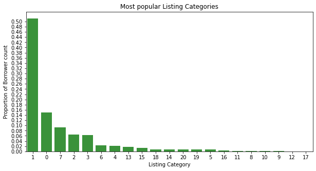

```python
# The listing category is a numeric categorization

#ordering the bars in descending order
bar_order=loan['ListingCategory (numeric)'].value_counts().index

#setting the figure size
plt.figure(figsize=[10,5])
#A countplot showing the number of loan seekers based on their indicated listing category
sb.countplot(data = loan, x = 'ListingCategory (numeric)', color = colour,order = bar_order)

#Setting axis label and plot title
plt.yticks(tick_props * n_listing_cat, y_tick_names)
plt.xlabel('Listing Category')
plt.ylabel(' Proportion of Borrower count ')
plt.title('Most popular Listing Categories');
```

#### Observation

Surprisingly, by a significant margin, the most popular listing category is debt consilidation. Other favoured categories are mostly undefined as they are listed as the 'not available' category and the 'other' category. Specified lisitngs of a notable amount also include home improvement and business. A more even distribution was expected.

> The next variable - **Lender Yield** - indicates the lender's profit in a loan. The idea is that lender institutions factor in the profitability of a loan in their decision to disburse it.

#### U.Fig-9 : What is the distribution of Lender Yield?

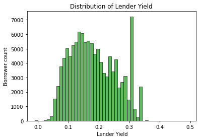

```python
#a histogram showing the distribution of Lender yield
sb.histplot(loan['LenderYield'],bins= 50, kde = False, color =colour)

#Setting the x-axis label and plot title;
plt.xlabel (' Lender Yield')
plt.ylabel('Borrower count')
plt.title('Distribution of Lender Yield');
```

> In order to look at trends it is vital to take a look at the number of loans across the **Years**

#### U.Fig-10 : What is the yearly distribution of loans

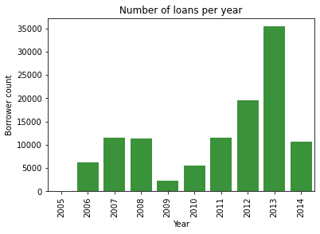

```python
#A countplot showing number of loans given per year
sb.countplot(data = loan, x='Year',color = colour)

#Rotating x-axis ticks to prevent overlap
plt.xticks (rotation =90)

#Setting y- axis label and plot title
plt.ylabel('Borrower count')
plt.title('Number of loans per year');
```

#### Observation

The graph shows a significant drop in the number loans in 2009. The reason for this should be looked into. From 2010, the graph shows a steady climb up to a significant(nearly 100%)increase between 2012 and 2013. This marks the end of the rise and is followed by a sharp decline in 2014.

> The distribution of loan amounts across the **states** will give insights into regions where the population has a high loan seeking behaviour.

#### U.Fig - 11 : What states have the highest and lowest loan count

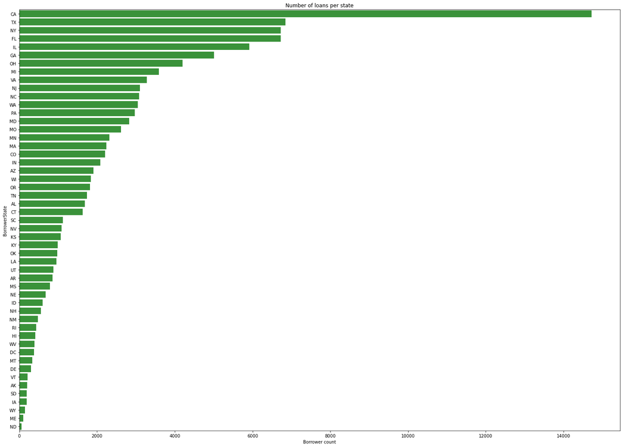

```python
#Determining appropriate figure size
plt.figure(figsize=(25,18))

#Define order of bar arrangement to go in descending order
type_order = loan['BorrowerState'].value_counts().index

#countplot showing number of loans given in each state
sb.countplot(data = loan, y = 'BorrowerState', color = colour, order =type_order)

#Setting x-axis label & plot title
plt.xlabel('Borrower count')
plt.title('Number of loans per state');
```

#### Observation

This is unexpected. California has the highest number of loans by a nearly 100% margin. Factors that affect this should be looked into. Texas, New York, and Florida show similar numbers of loans. North Dakota has the lowest number of loans

### Discuss the distribution(s) of your variable(s) of interest. Were there any unusual points? Did you need to perform any transformations?

> No transformations were required in order to derive insights from any of the variables of interest. A number of interesting insights were made, Including:
- Not owning a home has not significantly deterred borrowers from seeking loans
- Most borrowers fall within the income ranges of 25,000 USD -49,999 USD and 50,000 USD - 74,999 USD which falls into the lower middle class to middle class income brackets.
- Most loans were taken out for debt consolidation (the irony)
- In 2009 there was a shockingly low number of loans
- In 2013 there was a similarly shocking high number of loans, followed in 2014 by the lowest number of loans since 2011
- California's population has significant loan seeking behaviour

### Of the features you investigated, were there any unusual distributions? Did you perform any operations on the data to tidy, adjust, or change the form of the data? If so, why did you do this?

> The data was clear and informative without the need for further adjustments.

## Bivariate Exploration

#### B.Fig-1 : An Overview of the interaction of Loan Amount with other factors

The impact of select variables on the variable of interest - Original Loan Amount - is assessed. The variables assessed with Loan amount include:

- Borrower APR
- Investors
- Employment Status
- Income Range

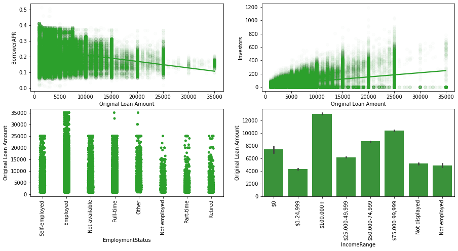

```python
plt.figure(figsize = [15, 7])

# left plot 1: Scatter plot
# Showing the relationship between Borrower APR and Original Loan Amount
ax1 = plt.subplot(2, 2, 1)
sb.regplot(data = loan, x ='LoanOriginalAmount', y= 'BorrowerAPR', x_jitter=0.2, scatter_kws ={'alpha': 0.01}, color=colour)
plt.xlabel('Original Loan Amount') #labeling the x-axis

# Right plot 1: Scatter plot
# Showing the relationship between Number of investors and Original Loan Amount
ax2 = plt.subplot(2, 2, 2)
sb.regplot(data = loan, x ='LoanOriginalAmount', y= 'Investors', x_jitter=0.7, scatter_kws ={'alpha': 0.01}, color = colour);
plt.xlabel('Original Loan Amount') #labeling the x-axis

# Left plot 2: Strip plot
# Showing the relationship between Eployment Status and Original Loan Amount
ax3 = plt.subplot(2, 2, 3)
sb.stripplot(data = loan , x = 'EmploymentStatus', y = 'LoanOriginalAmount', color = colour)
plt.ylabel('Original Loan Amount') #labeling the y-axis
plt.xticks(rotation =90) #rotating the x-axis ticks to prevent overlap

# Right plot 2: Barplot
# Showing the relationship between Income Range and Original Loan Amount
ax4 = plt.subplot(2,2,4)
sb.barplot(data = loan , x = 'IncomeRange', y = 'LoanOriginalAmount', color = colour)
plt.ylabel('Original Loan Amount') #labeling the y-axis
plt.xticks(rotation =90); #rotating the x-axis ticks to prevent overlap
```

#### Observation

The borrower APR shows a negative correlation with the original loan amount. The graph also shows that a large number of loans fall within the 1000 - 10,000 and have an even spread along the borrower APR range.

The graph shows a positive correlation with most loans falling within the 1000 - 10,000 loan amount and between 0-200 investors.

Employed borrowers recieve loans acrossthe range of loan amounts. Most other borrowers request loans between 1000-25,000, with "Full time" & "other" having exception.

The 100,000+ income earners expectedly request higher loans.

#### B.Fig-2 : Looking at the relationship between Prosper Score and the Homeowner status of the borrower

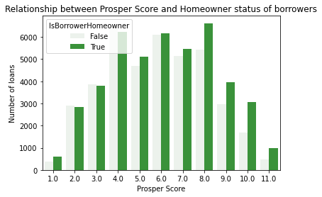

```python
#A countplot showing the interaction between the prosper score and borrower homeowner status
sb.countplot(data = loan,x ='ProsperScore', hue = 'IsBorrowerHomeowner', color = colour)

#Labeling the axes and adding a plot title
plt.xlabel('Prosper Score')
plt.ylabel('Number of loans')
plt.title('Relationship between Prosper Score and Homeowner status of borrowers');
```

#### Observation

Generally, the difference between homeowners & non-homeowners grows as prosper score increases. This indicates as expected that home ownership lowers a borrowers risk profile and possibly makes the borrower appealing for disbursal.

#### B.Fig-3 : Looking at the relationship between a borrowers income range and a borrower's APR

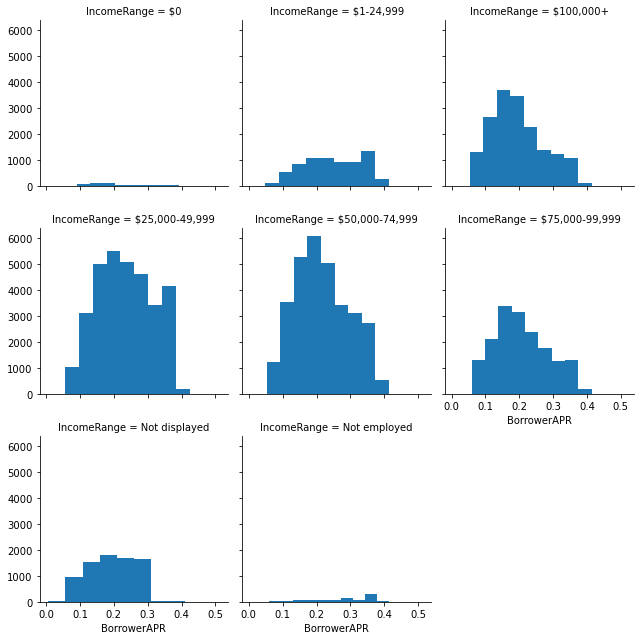

```python
#Faceting Borrower APR by Income Range
g = sb.FacetGrid(data =loan, col='IncomeRange', col_wrap= 3, margin_titles =True)
g.map(plt.hist, 'BorrowerAPR');
```

#### Observation

The earlier mentioned lower middle class - middle class show a wide range of Borrower APRs. The borrowers earning between 25,000 - 49,999 have an even spread of the amount of loans given.The 50,000 - 74,000 shows a decline in the amount loan given as the borrower APR increases

#### B.Fig-4 : Looking at the relationship between the borrower APR and the lender yield

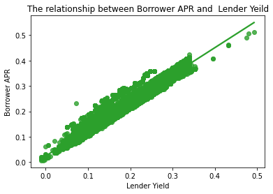

```python
#A scatterplot showing the relationship between Lender Yield and Borrower APR
sb.regplot(data = loan, x ='LenderYield', y= 'BorrowerAPR', color = colour)

#setting axis labels and plot title
plt.xlabel('Lender Yield')
plt.ylabel('Borrower APR')
plt.title('The relationship between Borrower APR and  Lender Yeild');
```

### Talk about some of the relationships you observed in this part of the investigation. How did the feature(s) of interest vary with other features in the dataset?

- Borrower APRs have a negative correlation with original loan amount i.e. interest rates generally reduce as the amount of loan increases.
- The number of investors and original loan amount have a positive correlation, meaning, the loan amount usually increases as the number of investors increases
- Employed & self-employed borrowers seek loans of a wide range of amounts whereas unemployed or retired borrowers usually seek loans between 1000 USD and 10,000 USD

### Did you observe any interesting relationships between the other features (not the main feature(s) of interest)?

- Even though borrowers do not account homeownership as a determining factor in their ability to seek loans, borrowers with lower risk prosper scores are more often homeowners.

## Multivariate Exploration

#### M.Fig-1 : Looking at Original loan amounts for each quarter in each year

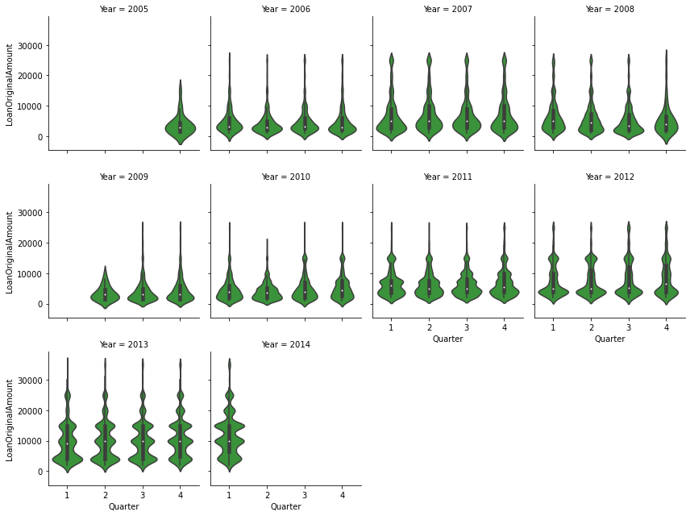

```python
#A multivariate facet grid showing the distribution of Original loan amount in each quarter of each year
g = sb.FacetGrid(data = loan, col = 'Year', col_wrap = 4)
g.map(sb.violinplot, 'Quarter', 'LoanOriginalAmount',color = colour);
```

#### M.Fig-2: Looking at how The Original loan amount and Borrower APRs vary across different porsper scores

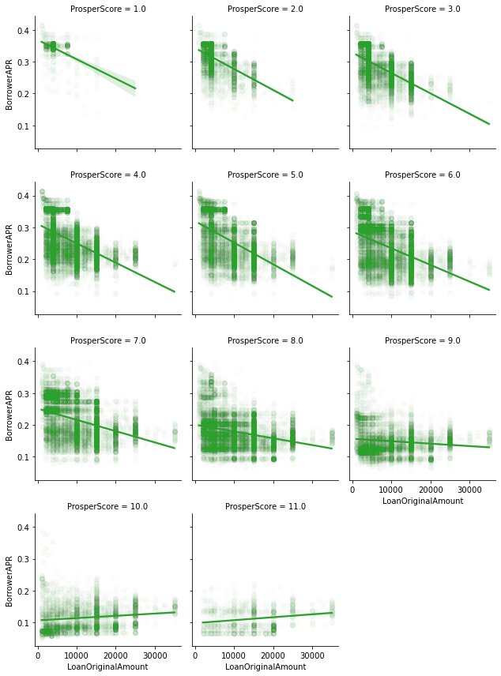

```python
#A multivariate facet grid showing the distribution of Original loan amount in each quarter of each year
g = sb.FacetGrid(data = loan, col = 'ProsperScore', col_wrap = 3)
g.map(sb.regplot, 'LoanOriginalAmount','BorrowerAPR', x_jitter=0.2, scatter_kws ={'alpha': 0.01}, color=colour);
```

#### Observation

- **1.0** Only a few borrowers have a prosper score of 1.0. These borrowers take out small loans generally ranging between 1000 USD and 10,000 USD at mostly high interest rates (Borrower APRs between 0.3 & 0.4)
- **2.0** Borrowers in this category generally seek loan amounts within the 1,000 USD - 20,000 USD range, with a few seeking loans between 20,000 USD and 30,000 USD. Interest rates include a mix of lows and highs with a range of 0.2 - 0.4
- **3.0** This category of borrowers take loan amounts across 1,000 USD to about 25,000 USD. This category has more borrowers having low interest rates i.e Borrower APRs between 0.1 and 0.2
- **4.0** A significant portion of borrowers in this category have loans between 1,000 USD and 10,000 USD and a borrower APR of about 0.35. Another significant portion of the borrower population in this category take out loans at 5000 USD, 10,000 USD and 15,000 USD with Borrower APRs spread through 0.1 - 0.4.
- **5.0 -6.0** A trend similar to borrowers of the 4.0 prosper score is seen in borrowers with prosper scores of 5.0 and 6.0
- **7.0 -9.0** Generally the loan amount sought by borrowers in this group rises.A significant proprtion of these borrowers also seek loans of bout 25,000 USD. Also this group of borrowers begins to show outliers that seek loans above 30,000 USD. Borrowers with prosper scores of 9.0 also show a general reduction in interest rates as most borrowers have interest rates betwee 0.25 and minimums below 0.1
- **10.0 and 11.0** These borrowers have the lowest risks. These borrowers seek loans ranging from as low as 1000 USD to the maximum possible amounts.They also have the lowest interest rates with maximum borrower APR generally aroun 0.25 and the minimum generally below 0.1

### Talk about some of the relationships you observed in this part of the investigation. Were there features that strengthened each other in terms of looking at your feature(s) of interest?

1. One of the most outstanding observations is the interaction between borrower APR, loan amount and prosper scores. Generally, borrowers with higher prosper scores accessed loans of higher amounts and had lower borrower APRs. This shows that prosper score has a negative correlation with borrower APR and a positive correlation with original loan amount
2. M.Fig-1 shows that from 2011 and significantly in the years 2013 and 2014 there was an increase in the number of borrowers seeking loans of hugher amounts (loans above 10,000USD)

### Were there any interesting or surprising interactions between features?

- The change in loan seeking behaviour in 2013 and 2014 are especially interesting as many societal, political and financial factors could have driven borrowers to seek out loans of higher amounts.

## Conclusions

1. Higher income earners access higher loan amounts
2. Annual loan amounts have been on the rise since 2010
3. Higher loan amounts have lower borrower APRs
4. California has the highest borrower count
5. Borrowers are more often home owners, especially those with higher prosper scores.

### Limitations

1. Dataset ends in 2014